# Übungsaufgaben R-Tutorium - Lösungen

Sommersemester 2021

# 1 Grundlagen

## 1.1 Grundrechenarten

$$10+25$$

```r
10 + 25
```

```
## [1] 35
```

$$50\cdot 2$$

```r
50 * 2
```

```
## [1] 100
```

$$\frac{27}{4}$$

```r
27 / 4
```

```
## [1] 6.75
```

$$500-650$$

```r
500 - 650
```

```
## [1] -150
```

$$2^4$$

```r
2^4 # Alternativ: 2**4
```

```
## [1] 16
```

$$\sqrt{3}\cdot 60$$

```r
sqrt(3) * 60
```

```
## [1] 103.923
```

$$50 \cdot (4+2)^3$$

```r
50 * (4 + 2)^3
```

```
## [1] 10800
```

## 1.2 Rechnungen mit Zwischenschritten

```r
a_  <- 10 + 25
b_  <- a_ * 40
c_ <- b_ - 100
d_ <- c_ * 3
e_ <- sqrt(d_)
f_ <- e_ / 1000
g_ <- f_^3
print(g_)
```

```
## [1] 0.0002435549
```

*Hinweis*: Um zu vermeiden, dass originäre `R`-Befehlte wie `c` überschrieben werden, wurden in der Lösung den Buchstaben immer ein `_` als Variablenname angefügt Bevor man einen Variablennamen vergibt, sollte man immer durch Eingabe in der Konsole überprüfen, ob dieser Name bereits vergeben ist. Bei `c` würde hätte man dann unmittelbar gemerkt, dass es sich hier bereits um eine Funktion handelt:

```r
c
```

```
## function (...)  .Primitive("c")
```

Man bekommt zwar keine Fehlermeldungen, wenn solche internen Funktionen überschrieben werden, das sollte aber unbedingt vermieden werden.

## 1.3 Vektorentypen und Dataframes

### 1.3.1 Tests auf Datentypen

```r
typeof(100)
```

```
## [1] "double"
```

```r
typeof("Tutorium")
```

```
## [1] "character"
```

```r
is.double(100)
```

```
## [1] TRUE
```

```r
is.character(100)
```

```
## [1] FALSE
```

```r
is.double("Tutorium")
```

```
## [1] FALSE
```

```r
is.character("Tutorium")
```

```
## [1] TRUE
```

### 1.3.2 Transformation von Datentypen

```r
at_vec <- "2"
at_vec_double <- as.double(at_vec)
is.double(at_vec_double)
```

```
## [1] TRUE
```

```r
at_vec_double * 2
```

```
## [1] 4
```

### 1.3.3 Listen und DataFrames

```r
Liste_1 <- list(
  "a" = 50:55,
  "b" = 60:65,
  "c" = 70:75
)
Liste_1
```

```
## $a
## [1] 50 51 52 53 54 55
##
## $b
## [1] 60 61 62 63 64 65
##
## $c
## [1] 70 71 72 73 74 75
```

```r
Data_Frame_1 <- as.data.frame(Liste_1)
Data_Frame_1
```

```
##    a  b  c
## 1 50 60 70
## 2 51 61 71
## 3 52 62 72
## 4 53 63 73
## 5 54 64 74
## 6 55 65 75
```

### 1.3.4 Manuelle Konstruktion eines DataFrames

```r
Bundeslaender <- data.frame(
  "Bundesland" = c("Berlin", "Hamburg", "Bremen"),
  "Flaeche" = c(892, 755, 419)
)
Bundeslaender
```

```
##   Bundesland Flaeche
## 1     Berlin     892
## 2    Hamburg     755
## 3     Bremen     419
```

```r
str(Bundeslaender)
```

```
## 'data.frame':    3 obs. of  2 variables:
##  $ Bundesland: chr  "Berlin" "Hamburg" "Bremen"
##  $ Flaeche   : num  892 755 419
```

Oder:

```r
typeof(Bundeslaender$Bundesland)
```

```
## [1] "character"
```

```r
typeof(Bundeslaender$Flaeche)
```

```
## [1] "double"
```

Erstellen eines `tibble`:

```r
require(tibble)
Bundeslaender <- tibble::tibble(
  "Bundesland" = c("Berlin", "Hamburg", "Bremen"),
  "Flaeche" = c(892, 755, 419)
)
Bundeslaender
```

```
## # A tibble: 3 x 2
##   Bundesland Flaeche
##   <chr>        <dbl>
## 1 Berlin         892
## 2 Hamburg        755
## 3 Bremen         419
```

### 1.3.5 DataFrames und Listen (optional)

Welchen Typ hat ein DataFrame? Welchen Typ hat ein `tibble`? Welchen Typ hat eine Liste? Was sagt uns das über die zugrundeliegende Objektstruktur in `R`?

```r
require(tibble)
list_expl <- list("a"=1:3, "b"=4:6)
data_frame_expl <- as.data.frame(list_expl)
tibble_expl <- tibble::as_tibble(list_expl)
```

```r
typeof(list_expl)
```

```
## [1] "list"
```

```r
typeof(data_frame_expl)
```

```
## [1] "list"
```

```r
typeof(tibble_expl)
```

```
## [1] "list"
```

Bei allen drei Objekten handelt es sich um Listen! Das liegt daran, dass es sich beim DataFrame und beim Tibble nicht um ‘genuine’ Typen handelt, sondern um so genannte S3-Klassen, welche die ‘genuinen’ Typen wie `list` mit bestimmten Features modifiziert. Das erkennen wir über Anwendung der Funktion `class()`:

```r
class(list_expl)
```

```
## [1] "list"
```

```r
class(data_frame_expl)
```

```
## [1] "data.frame"
```

```r
class(tibble_expl)
```

```
## [1] "tbl_df"     "tbl"        "data.frame"
```

```r
is.data.frame(tibble_expl)
```

```
## [1] TRUE
```

```r
is.data.frame(data_frame_expl)
```

```
## [1] TRUE
```

Aber:

```r
tibble::is_tibble(data_frame_expl)
```

```
## [1] FALSE
```

```r
tibble::is_tibble(tibble_expl)
```

```
## [1] TRUE
```

Das hat mit der objektorientierten Struktur von R zu tun. Es ist in der Praxis nur relevant wenn wir Operationen durchführen, die für unterschiedliche Klassen unterschiedlich funktionieren. Das werden wir später z.B. bei der Funktion `summary()` noch merken. Es ist aber in der Praxis zu Beginn weniger relevant. Mehr Details gibt es im Skript und [hier](https://adv-r.hadley.nz/vectors-chap.html#s3-atomic-vectors).

# 2 R-Markdown

TBA

# 3 Datenaufbereitung

## 3.1 Filtern und Übersetzen

Verwendete Pakete:

```r
require(tidyverse)
require(here)
require(data.table)
require(countrycode)
require(knitr)
```

Einlesen der Daten:

```r
daten_pfad <- here::here("data/BIP_Konsum.csv")

daten <- data.table::fread(
  daten_pfad, colClasses = c("double"))
head(daten, 3)
```

```
##    Jahr Konsumausgaben          BIP
## 1: 1992   1.601342e+12 2.077722e+12
## 2: 1993   1.611040e+12 2.057856e+12
## 3: 1994   1.647699e+12 2.108425e+12
```

Filtern der Beobachtungen:

```r
daten_1997_2015 <- daten %>%
  dplyr::filter(Jahr > 1997 & Jahr < 2015)
```

Übersetzung:

```r
daten_uebersetzt <- daten %>%
  dplyr::rename(
    Year = Jahr,
    ConsumerSpending = Konsumausgaben,
    GDP = BIP
  )
head(daten_uebersetzt, 2)
```

```
##    Year ConsumerSpending          GDP
## 1: 1992     1.601342e+12 2.077722e+12
## 2: 1993     1.611040e+12 2.057856e+12
```

Optionale Alternative bei der die Namen als `character` kodiert sind (nützlich für die Automatisierung):

```r
daten_uebersetzt <- daten %>%
  dplyr::rename(
    !!as.name("Year") := !!as.name("Jahr"),
    !!as.name("ConsumerSpending") := !!as.name("Konsumausgaben"),
    !!as.name("GDP") := !!as.name("BIP")
  )
head(daten_uebersetzt, 2)
```

```
##    Year ConsumerSpending          GDP
## 1: 1992     1.601342e+12 2.077722e+12
## 2: 1993     1.611040e+12 2.057856e+12
```

## 3.2 Herunterladen eines OECD Datensatzes

Geht auf der Website links über den Reiter `Finance`auf den Tab `Central Government Debt`. Dort findet ihr eine gleichnamige Tabelle, aus dem ihr die Daten herausziehen könnt Folgende Einstellungen sind dabei notwendig, die ihr oben durch einen Klick auf `Customize` vornehmen könnt:

Variable: `Total central government debt % of GDP` Type: Stocks: `Outstanding Amounts` Unit: `Percantage` Frequency: `Annual` Time Period: `2000 - 2010` Countries: `Alle Länder von Australia bis United States`

Dann könnt ihr den Datensatz herunterladen und als `csv` speichern.

## 3.3 Aufbereitung des OECD Datensatzes

1. Einlesen:

```r
Debt_Pfad <- here::here("data/GovDebt.csv")

Debt <- data.table::fread(Debt_Pfad)
str(Debt, vec.len = 3)
```

```
## Classes 'data.table' and 'data.frame':   370 obs. of  15 variables:
##  $ COU        : chr  "AUS" "AUS" "AUS" ...
##  $ Country    : chr  "Australia" "Australia" "Australia" ...
##  $ DTYP       : chr  "AMT" "AMT" "AMT" ...
##  $ Type       : chr  "Stocks: Outstanding amounts" "Stocks: Outstanding amounts" "Stocks: Outstanding amounts" ...
##  $ FREQ       : chr  "A" "A" "A" ...
##  $ Frequency  : chr  "Annual" "Annual" "Annual" ...
##  $ UNIT       : chr  "PCT" "PCT" "PCT" ...
##  $ Unit       : chr  "Percentage" "Percentage" "Percentage" ...
##  $ DVAR       : chr  "P1" "P1" "P1" ...
##  $ Variable   : chr  "Total central government debt % of GDP" "Total central government debt % of GDP" "Total central government debt % of GDP" ...
##  $ TIME       : int  2000 2001 2002 2003 2004 2005 2006 2007 ...
##  $ Time period: int  2000 2001 2002 2003 2004 2005 2006 2007 ...
##  $ Value      : num  11.36 9.55 8.58 7.55 ...
##  $ Flag Codes : logi  NA NA NA NA ...
##  $ Flags      : logi  NA NA NA NA ...
##  - attr(*, ".internal.selfref")=<externalptr>
```

2. Auswahl der Zeilen:

```r
Debt_1 <- Debt %>%
  dplyr::select(Country, TIME, Value)

# Alternativ mit characters
Debt_1 <- Debt %>%
  dplyr::select(
    dplyr::all_of(c("Country", "TIME", "Value"))
    )
head(Debt_1, 2)
```

```
##      Country TIME  Value
## 1: Australia 2000 11.361
## 2: Australia 2001  9.552
```

3. Filtern nach Deutschland und Zeitraum:

```r
Debt_1_Filtered <- Debt_1 %>%
  dplyr::filter(
    Country == "Germany",
    TIME >= 2005,
    TIME <= 2010
  )
Debt_1_Filtered
```

```
##    Country TIME  Value
## 1: Germany 2005 40.832
## 2: Germany 2006 41.232
## 3: Germany 2007 39.550
## 4: Germany 2008 39.550
## 5: Germany 2009 44.205
## 6: Germany 2010 44.403
```

Oder alle Schritte kombiniert mit Hilfe von `%>%`:

```r
debt_filtered <- data.table::fread(Debt_Pfad) %>%
  dplyr::select(
    dplyr::all_of(c("Country", "TIME", "Value"))
    ) %>%
  dplyr::filter(
    Country == "Germany",
    TIME >= 2005,
    TIME <= 2010
  )
```

In jedem Fall sollte man immer verifizieren, ob die Länder-Jahre-Kombinationen eindeutig sind, z.B. durch:

```r
debt_filtered_unique <- debt_filtered %>%
  dplyr::distinct(Country, TIME, .keep_all = TRUE)
nrow(debt_filtered_unique) - nrow(debt_filtered)
```

```
## [1] 0
```

Da beide Datensätze die gleiche Anzahl an Zeilen haben, gibt es keine Duplikate. Es gibt verschiedene (und je nach Anwendung effizientere) Methoden um Duplikatore zu finden, aber für die meisten Fälle ist `dplyr::distinct()` ausreichend.

Bereitet den gerade heruntergeladenen Datensatz (den ihr ansonsten auch als `GovDebtOECD.csv` im Ordner `data` findet) auf indem ihr nur noch die Variablen `Country`, `TIME` und `Value` behaltet und die Daten auf Beobachtungen für Deutschland zwischen 2005 und 2010 beschränkt. Stellt sicher, dass ihr für jede Jahr-Land Kombination tatsächlich nur eine Beobachtung im Datensatz habt.

## 3.4 Lange und breite Datensätze kombinieren

Nachdem wir die Daten heruntergeladen und unter `data/raw/AMECO7.txt` und `data/raw/swiid8_0_summary.csv` gespeichert haben transformieren wir beide Datensätze zunächst in die lange Form (beim SWIID ist die relevante Spalte der `gini_disp`):

```r
ameco_7 <- fread(
  here("data/raw/AMECO7.txt"), fill = T, header = T,
  colClasses = c(rep("character", 5), rep("double", 63))
  ) %>%
  filter(
    TITLE==paste("Adjusted wage share: total economy: as percentage of",
                 "GDP at current prices (Compensation per employee as",
                 "percentage of GDP at market prices per person employed.)")
    ) %>%
  select(
    -any_of(c("V68", "SUB-CHAPTER", "CODE", "TITLE", "UNIT"))
    ) %>%
  pivot_longer(
    names_to = "Jahr", values_to = "AWS",
    cols = one_of(as.character(1960:2021))
    ) %>%
  mutate(Jahr=as.double(Jahr))

swiid <- fread(
  here("data/raw/swiid8_0_summary.csv"),
  select = c("country"="character",
             "year"="double",
             "gini_disp"="double"))
```

Wir verwenden nun die Funktion `inner_join()`, da wir ja keine fehlenden Werte haben wollen. Vorher übersetzen wir noch die Ländernamen beider Datensätze in das `iso3c` Format:

```r
ameco_7 <- ameco_7 %>%
  mutate(
    COUNTRY=countrycode(COUNTRY, "country.name", "iso3c")
    ) %>%
  filter(!is.na(COUNTRY))

swiid <- swiid %>%
  mutate(
    country=countrycode(country, "country.name", "iso3c")
    ) %>%
  filter(!is.na(country))

full_data <- inner_join(
  ameco_7, swiid,
  by=c("COUNTRY"="country", "Jahr"="year"))
```

Nun können wir noch die Kontinente hinzufügen und die gewünschten gruppierten deskriptiven Statistiken berechnen:

```r
final_data <- full_data %>%
  mutate(
    Region=countrycode(
      COUNTRY, origin = "iso3c", destination = "continent")
    ) %>%
  group_by(Region) %>%
  summarise(
    across(
      .cols = all_of(c("AWS", "gini_disp")),
      .fns =  list(mean = ~mean(.x, na.rm=T),
                   sd = ~sd(.x, na.rm=T)),
      .groups = "drop"))
knitr::kable(final_data)
```

| Region | AWS_mean | AWS_sd | gini_disp_mean | gini_disp_sd |
| --- | --- | --- | --- | --- |
| Americas | 55.44769 | 8.090756 | 37.68408 | 8.122685 |
| Asia | 62.62486 | 11.093583 | 31.12471 | 5.523268 |
| Europe | 56.29696 | 6.704024 | 28.24853 | 3.895128 |
| Oceania | 55.54349 | 4.810261 | 30.40349 | 2.435012 |

# 4 Visualisierung

## 4.1 Liniengraph zu privaten Krankenversicherungen in Deutschland

```r
require(tidyverse)
require(data.table)
require(scales)
require(here)
```

```r
daten_pfad <- here::here("data/PrivateInsuranceGermany.csv")

priv_vers_de <- data.table::fread(
  daten_pfad, colClasses = c("double", "double", "character")
  ) %>%
  ggplot2::ggplot(
  data = .,
  mapping = aes(x = Year, y = PercPop)
) +
  ggplot2::geom_line() +
  ggplot2::scale_x_continuous(name = "Jahr") +
  ggplot2::scale_y_continuous(
    name = "Anteil Privatversicherungen",
    labels = scales::percent_format(scale = 1, accuracy = 1),
    limits = c(0, 40)
    ) +
  ggplot2::labs(
    title = "Entwicklung der Privatversicherungen in Deutschland",
    subtitle = "Zeitraum von 1991 bis 2018",
    caption = "Daten: OECD Statistics"
  ) +
  theme_bw() +
  theme(
    panel.border = element_blank(),
    axis.line = element_line(),
    axis.title.x = element_blank()
  )
```

## 4.2 Ein Balkendiagramm

```r
require(tidyverse)
```

```r
werte <- tibble::tibble(
  Gruppe = c(
    "Finish no school",
    "Finish 1 year",
    "Finish 3 years",
    "Graduate, 2.0 GPA",
    "Graduate, 3.0 GPA",
    "Graduate, 3.75 GPA"),
  Einkommen = c(
    480, 510, 620,
    800, 920, 1050
  ))

schwabisch_plot <- ggplot(
  data = werte,
  mapping = aes(x=reorder(Gruppe, -Einkommen), y=Einkommen)
  ) +
  geom_bar(
    stat = "identity", width = 0.5, color="#13294b", fill="#13294b"
    ) +
  scale_y_continuous(
    breaks = seq(0, 1200, 200), expand = expansion()
    ) +
  coord_flip() +
  labs(
    title = "Discounted Expected Lifetime Earnings, VN(t')",
    subtitle = "(Income in thousands)",
    caption = paste(
      "Author's calculations using numbers inferred from text",
      "in Stinebrickner and Stinebrickner (2013).")
    ) +
  theme_bw() +
  theme(panel.border = element_blank(),
        axis.ticks = element_blank(),
        axis.title = element_blank(),
        axis.line = element_line(),
        panel.grid = element_blank(),
        plot.title = element_text(face = "bold"),
        panel.grid.major.x = element_line(colour = "grey"))
```

## 4.3 Zweil Balkendiagramme

```r
require(data.table)
require(here)
library(scales)
require(tidyverse)
require(ggpubr)
```

```r
ameco_swiid_data <- fread(here("data/ameco_swiid_tidy.csv"))

aws_plot <- ggplot(
  data = ameco_swiid_data,
  mapping = aes(x=Region, y=AWS_mean)
  ) +
  geom_bar(
    stat = "identity", width = 0.5, color="#13294b", fill="#13294b"
    ) +
  geom_errorbar(
    aes(ymin=AWS_mean-0.5*AWS_sd, ymax=AWS_mean+0.5*AWS_sd),
    width = 0.4, color = "grey"
    ) +
  labs(title="Adj. Wage Share", caption = "Quelle: AMECO") +
  scale_y_continuous(
    name="Lohnanteil in %",
    expand = expansion(c(0, 0), c(0,5)),
    labels = scales::percent_format(accuracy = 1, scale = 1)
    ) +
  theme_bw() +
  coord_flip() +
  theme(axis.title.y = element_blank(),
        panel.border = element_blank(),
        axis.line = element_line(),
        axis.ticks.y = element_blank(),
        panel.grid.major.y = element_blank(),
        panel.grid.minor.y = element_blank())

gini_plot <- ggplot(
  data = ameco_swiid_data,
  mapping = aes(x=Region, y=gini_disp_mean)
  ) +
  geom_bar(
    stat = "identity", width = 0.5, color="#13294b", fill="#13294b"
    ) +
  geom_errorbar(
    aes(ymin=gini_disp_mean-0.5*AWS_sd, ymax=gini_disp_mean+0.5*AWS_sd),
    width = 0.4, color = "grey"
    ) +
  labs(title="Gini (post-Steuer)", caption = "Quelle: SWIID") +
  scale_y_continuous(
    name="Gini (post-Steuer)",
    expand = expansion(c(0, 0), c(0,5)),
    labels = scales::percent_format(accuracy = 1, scale = 1)
    ) +
  coord_flip() +
  theme_bw() +
  theme(axis.title.y = element_blank(),
        panel.border = element_blank(),
        axis.line = element_line(),
        axis.ticks.y = element_blank(),
        panel.grid.major.y = element_blank(),
        panel.grid.minor.y = element_blank())

full_plot <- ggpubr::ggarrange(aws_plot, gini_plot, nrow = 2)
```

```r
ggsave(plot = full_plot,
       filename = here("output/vis_ameco_swiid.png"),
       width = 6, height = 4)
```

# 5 Formalia

TBA

# 6 Regressionsanalyse I

TBA

# 7 Monte-Carlo-Simulationen

## 7.1 Der Zentrale Grenzwertsatz

```r
require(tidyverse)
require(ggpubr)
require(icaeDesign)
```

```r
set.seed(123)
n_samples <- c(5, 10, 50, 500, 1000, 5000)
sample_means <- list()
mean_plots <- list()
for (i in seq_along(n_samples)){
  sample_means[[paste0("n_", n_samples[i])]] <- tibble(
    means = purrr::map_dbl(
      .x = 1:n_samples[i], .f = ~mean(runif(n = 20)))
    )
  mean_plots[[paste0("n_", n_samples[i])]] <- ggplot(
    data = sample_means[[paste0("n_", n_samples[i])]],
    mapping = aes(x=means)
  ) +
    labs(title = paste0("Stichprobe: ", n_samples[i])) +
    geom_density() + theme_icae()
}
```

Beachten Sie die Verwendung der Funktion `purrr::map_dbl()`, mit der wir das gleiche wie mit einem einfachen `for`-Loop erreichen können. Sie führt die Funktion nach dem Argument `.f` so oft aus wie der Vektor beim Argument `.x` lang ist und gibt die Ergebnisse als Vektor aus. Für mehr Infos siehe z.B. [hier](https://r4ds.had.co.nz/iteration.html#the-map-functions).

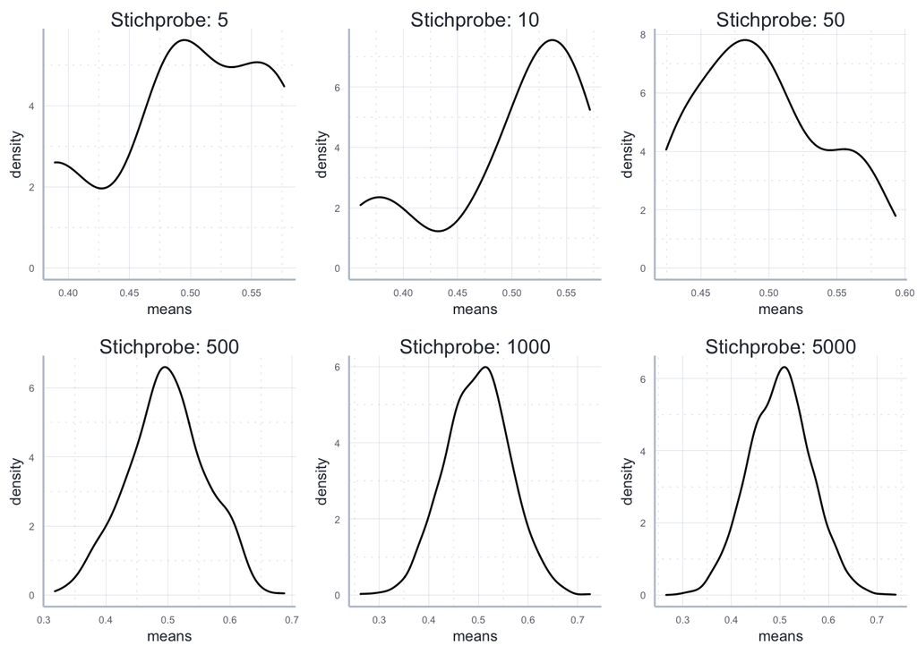

```r
ggpubr::ggarrange(plotlist = mean_plots)
```

## 7.2 Das Gesetz der großen Zahl

```r
require(tidyverse)
require(ggpubr)
require(icaeDesign)
```

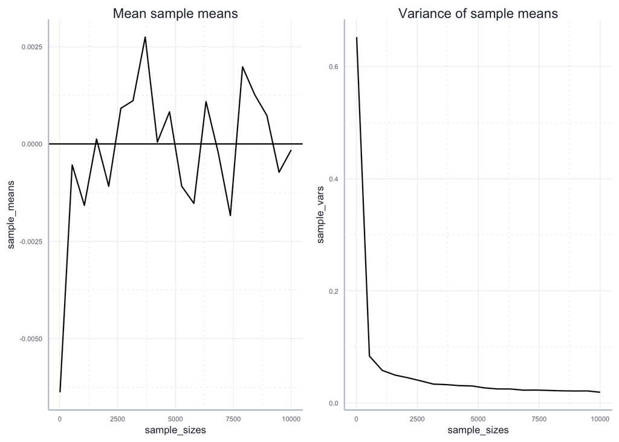

```r
set.seed(1)
samples <- 20
nb_samples <- 500
sample_sizes <- seq(10, 10000, length.out = samples)
sample_means <- rep(NA, samples)
sample_vars <- rep(NA, samples)
for (i in 1:samples){
  sample_size <- sample_sizes[i]

  samples_used <- purrr::map_dbl(.x = 1:nb_samples, .f = ~mean(
    rnorm(n = sample_size, mean = 0, sd = 2))
    )
  sample_means[i] <- mean(samples_used)
  sample_vars[i] <- sd(samples_used)
}

mean_plot <- ggplot(
  tibble(sample_sizes, sample_means), aes(x=sample_sizes, y=sample_means)
  ) +
  geom_line() + geom_hline(yintercept = 0) +
  ggtitle("Mean sample means") +
  theme_icae()

var_plot <- ggplot(
  tibble(sample_sizes, sample_vars), aes(x=sample_sizes, y=sample_vars)
  ) +
  ggtitle("Variance of sample means") +
  geom_line() +
  theme_icae()

ggpubr::ggarrange(mean_plot, var_plot)
```

## 7.3 OLS und nicht-normalverteilte Fehler

```r
require(tidyverse)
require(data.table)
require(knitr)
require(icaeDesign)
```

Spezifikation der Parameter:

```r
set.seed(123)
mcs_runs <- 1000
beta_0 <- 1
beta_1 <- 3
stichproben_n <- c(10, 20, 50, 100)
```

Definition einer Funktion, welche die MCS für eine gegebene Stichprobengröße ausführt:

```r
do_mcs <- function(stichprobengroesse, mcs_runs){
  # Erstellen der deterministischen Variablen:
  x_var <- runif(stichprobengroesse)
  y_determ <- beta_0 + beta_1*x_var
  data_det <- tibble("x"=x_var, "y_det"=y_determ)
  beta_1hat_norm <- rep(NA, mcs_runs)
  beta_1se_norm <- rep(NA, mcs_runs)
  beta_1hat_chi <- rep(NA, mcs_runs)
  beta_1se_chi <- rep(NA, mcs_runs)
  for (i in 1:mcs_runs){
    # Ziehung der Fehlerterme und Berechnung der Stichprobe
    normal_errors <- scale(rnorm(n = stichprobengroesse))
    nonnormal_errors <- scale(rchisq(n = stichprobengroesse, df = 1))
    sample_obtained <- data_det %>%
      dplyr::mutate(
        y_norm = y_det + normal_errors,
        y_chi = y_det + nonnormal_errors[,1]
      )

    # Schätzung des Modells
    linreg_norm <- summary(lm(y_norm~x, data = sample_obtained))
    beta_1hat_norm[i] <- coef(linreg_norm)[2]
    beta_1se_norm[i] <- coef(linreg_norm)[4]

    linreg_chi <- summary(lm(y_chi~x, data = sample_obtained))
    beta_1hat_chi[i] <- coef(linreg_chi)[2]
    beta_1se_chi[i] <- coef(linreg_chi)[4]
  }
  tibble(
    "n" = rep(stichprobengroesse, mcs_runs),
    "beta_1hat_norm" = beta_1hat_norm,
    "beta_1se_norm" = beta_1se_norm,
    "beta_1hat_chi" = beta_1hat_chi,
    "beta_1se_chi" = beta_1se_chi
  )
}
```

Simulation für verschiedene Stichprobengrößen:

```r
mcs_results <- list()
for (i in seq_along(stichproben_n)){
  mcs_results[[i]] <- do_mcs(
    stichprobengroesse = stichproben_n[i], mcs_runs = mcs_runs)
}
mcs_results_full <- data.table::rbindlist(mcs_results)
```

Visualisierung der Ergebnisse:

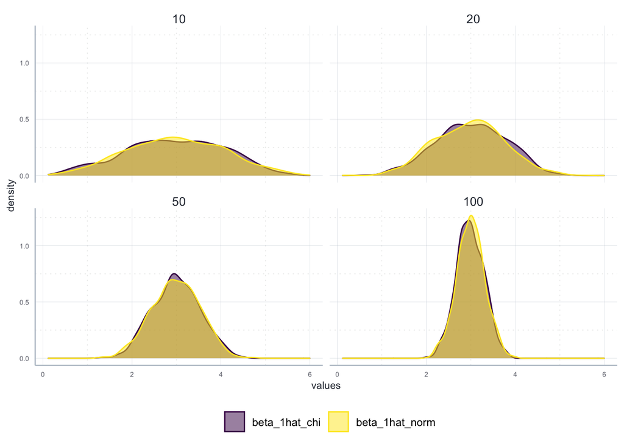

```r
mcs_results_full %>%
  select(all_of(c("beta_1hat_norm", "beta_1hat_chi", "n"))) %>%
  pivot_longer(
    cols = all_of(c("beta_1hat_norm", "beta_1hat_chi")),
    names_to = "vars", values_to = "values") %>%
  dplyr::mutate(stichprobe=factor(n)) %>%
  ggplot(data = ., aes_string(x="values", color="vars", fill="vars")) +
  geom_density(alpha=0.5) +
  scale_color_viridis_d(aesthetics = c("color", "fill")) +
  facet_wrap(~stichprobe) +
  theme_icae()
```

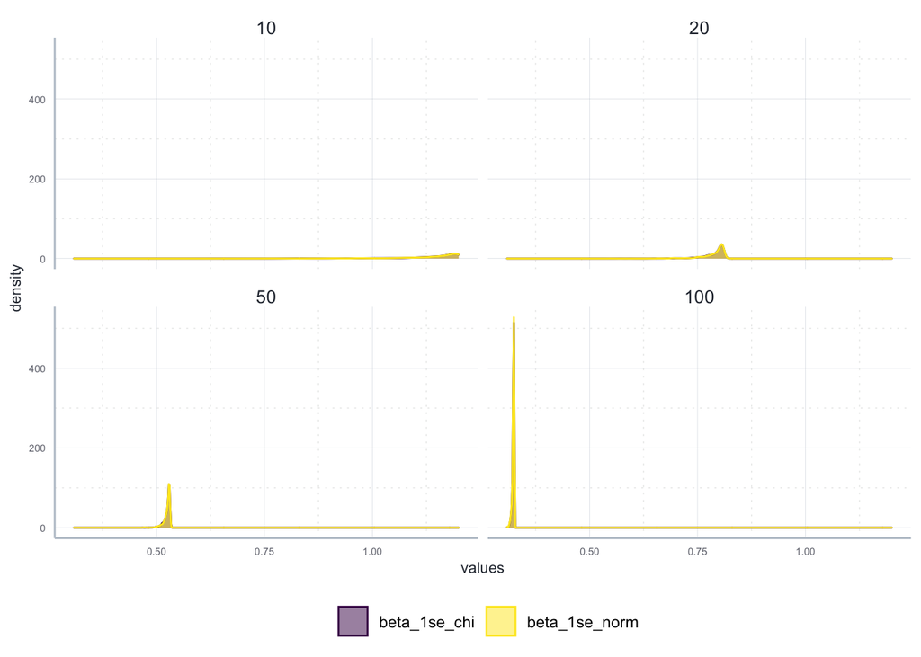

```r
mcs_results_full %>%
  select(all_of(c("beta_1se_chi",  "beta_1se_norm", "n"))) %>%
  pivot_longer(
    cols = all_of(c("beta_1se_norm", "beta_1se_chi")),
    names_to = "vars", values_to = "values") %>%
  dplyr::mutate(stichprobe=factor(n)) %>%
  ggplot(data = ., aes_string(x="values", color="vars", fill="vars")) +
  geom_density(alpha=0.5) +
  scale_color_viridis_d(aesthetics = c("color", "fill")) +
  facet_wrap(~stichprobe) +
  theme_icae()
```

Zusammenfassende Statistiken:

```r
mcs_results_full %>%
  dplyr::mutate(
    sq_errors_normal = (beta_1hat_norm - beta_1)**2,
    sq_errors_chi = (beta_1hat_chi - beta_1)**2
  ) %>%
  group_by(n) %>%
  summarise(
    mean_beta1_hat_norm=mean(beta_1hat_norm),
    mean_beta1_hat_chi=mean(beta_1hat_chi),
    mean_se_norm = mean(beta_1se_norm),
    mean_se_chi = mean(beta_1se_chi),
    mse_beta1_norm=mean(sq_errors_normal),
    mse_beta_1_chi=mean(sq_errors_chi)
  ) %>%
  knitr::kable(
    digits = 3,
    col.names = c("n", "B1 (norm)", "B1 (chi)", "SE (norm)",
                  "SE (chi)", "MSE (norm)", "MSE (chi)"))
```

| n | B1 (norm) | B1 (chi) | SE (norm) | SE (chi) | MSE (norm) | MSE (chi) |
| --- | --- | --- | --- | --- | --- | --- |
| 10 | 2.984 | 2.965 | 1.132 | 1.131 | 1.195 | 1.216 |
| 20 | 2.971 | 3.009 | 0.787 | 0.787 | 0.621 | 0.623 |
| 50 | 2.988 | 2.998 | 0.525 | 0.525 | 0.292 | 0.285 |
| 100 | 2.999 | 2.988 | 0.324 | 0.324 | 0.101 | 0.098 |

Insgesamt sind also bereits bei sehr kleinen Stichproben kaum Performance-Unterschiede zu erkennen.

# 8 Regressionsanalyse II

TBA

# 9 Regressionsanalyse III

TBA